# Práctica 8: Regresión lineal múltiple

> Alumno: Miguel Ángel Fernández Gutiérrez <mianfg@correo.ugr.es>

## Ejercicio 1

Inspecciona el fichero (desde por ejemplo el bloc de notas) para comprobar la estructura que tiene del fichero y el tipo de datos. Teniendo esto en cuenta carga después los datos en R, almacenándolos en un data frame con nombre `hatco` donde las variables de tipo factor se identifiquen como tal.

```r
hatco <- read.csv('./data/hatco2.csv', header=T, as.is=NA)
hatco
```

| empresa | tamano | adquisic | tindustr | tsitcomp | velocidad | precio | flexprec | imgfabri | servconj | imgfvent | calidadp | fidelidad | nfidelidad | nsatisfac |
| --- | --- | --- | --- | --- | --- | --- | --- | --- | --- | --- | --- | --- | --- | --- |
| 1 | pequeña | descentralizada | clase A | nueva tarea | 4.1 | 0.6 | 6.9 | 4.7 | 2.4 | 2.3 | 5.2 | 32.0 | medio | bajo |
| 2 | grande | centralizada | otras industrias | nueva tarea | 1.8 | 3.0 | 6.3 | 6.6 | 2.5 | 4.0 | 8.4 | 43.0 | medio | bajo |
| 3 | grande | centralizada | clase A | recompra modificada | 3.4 | 5.2 | 5.7 | 6.0 | 4.3 | 2.7 | 8.2 | 48.0 | medio | alto |
| 4 | grande | centralizada | clase A | nueva tarea | 2.7 | 1.0 | 7.1 | 5.9 | 1.8 | 2.3 | 7.8 | 32.0 | medio | bajo |
| 5 | pequeña | descentralizada | clase A | recompra directa | 6.0 | 0.9 | 9.6 | 7.8 | 3.4 | 4.6 | 4.5 | 58.0 | alto | alto |
| 6 | grande | centralizada | clase A | recompra modificada | 1.9 | 3.3 | 7.9 | 4.8 | 2.6 | 1.9 | 9.7 | 45.0 | medio | bajo |
| 7 | pequeña | descentralizada | clase A | nueva tarea | 4.6 | 2.4 | 9.5 | 6.6 | 3.5 | 4.5 | 7.6 | 46.0 | medio | alto |
| 8 | grande | centralizada | otras industrias | recompra modificada | 1.3 | 4.2 | 6.2 | 5.1 | 2.8 | 2.2 | 6.9 | 44.0 | medio | bajo |
| 9 | pequeña | descentralizada | clase A | recompra directa | 5.5 | 1.6 | 9.4 | 4.7 | 3.5 | 3.0 | 7.6 | 63.0 | alto | alto |
| 10 | grande | centralizada | otras industrias | recompra modificada | 4.0 | 3.5 | 6.5 | 6.0 | 3.7 | 3.2 | 8.7 | 54.0 | alto | alto |

[output cut: 90 more lines]

## Ejercicio 2

Observa el gráfico en relación a los dos puntos siguientes, ¿qué podrías decir?

- Advertir si existe relación lineal entre la respuesta y cada una de las variables explicativas.
- Descubrir si hay variables explicativas que sean aproximadamente colineales al resto.

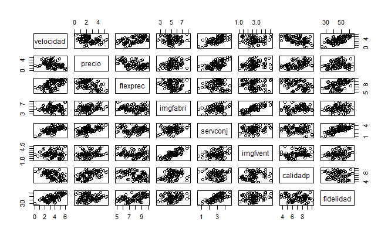

```r
plot(hatco[,c(6:13)])
```

No parece que haya ninguna relación lineal a la vista, ni tampoco podemos ver sencillamente variables que sean colineales (todas están bastante dispersas). Las “más lineales” son `servconj`-`fidelidad`.

## Ejercicio 3

Repite el razonamiento anterior para las otras percepciones $x_2, … , x_7$. ¿Qué puedes decir de la significación individual del resto de percepciones al 5%?

```r
mod1<-lm(fidelidad~velocidad+precio+flexprec+imgfabri+servconj+imgfvent+calidadp, hatco)
summary(mod1)
```

```
Call:
lm(formula = fidelidad ~ velocidad + precio + flexprec + imgfabri +
    servconj + imgfvent + calidadp, data = hatco)

Residuals:
     Min       1Q   Median       3Q      Max
-12.9759  -1.9491   0.5896   2.8144   6.7565

Coefficients:
             Estimate Std. Error t value Pr(>|t|)
(Intercept) -10.16148    4.97696  -2.042   0.0440 *
velocidad    -0.04352    2.01273  -0.022   0.9828
precio       -0.67891    2.09025  -0.325   0.7461
flexprec      3.36197    0.41125   8.175 1.56e-12 ***
imgfabri     -0.04101    0.66683  -0.061   0.9511
servconj      8.34537    3.91830   2.130   0.0359 *
imgfvent      1.29147    0.94720   1.363   0.1761
calidadp      0.56295    0.35544   1.584   0.1167
---
Signif. codes:  0 ‘***’ 0.001 ‘**’ 0.01 ‘*’ 0.05 ‘.’ 0.1 ‘ ’ 1

Residual standard error: 4.424 on 92 degrees of freedom
Multiple R-squared:  0.775, Adjusted R-squared:  0.7578
F-statistic: 45.26 on 7 and 92 DF,  p-value: < 2.2e-16
```

Nota: en cada punto tomaremos $H_0:\beta_i=0$, $H_1:\beta_i\neq0$, siendo $\beta_i$ el coeficiente correspondiente a cada variable.

Únicamente en las variables `flexprec` y `servconj` hay evidencia suficiente para rechazar $H_0$ al 5% de significación.

## Ejercicio 4

Considerando un nivel de significación del 5 %, ¿se podría prescindir del término constante en el modelo? ¿Y al 1 %?

Hay evidencia suficiente para rechazar al 5% de significación, pero no al 1%.

## Ejercicio 5

Calcula los residuos estandarizados $r_i$ y representa el gráfico de dispersión de los pares $(\hat{y}_i,r_i)$. A continuación representa para cada percepción $x_j$, gráficos de dispersión de los pares $(x_{ij},r_i)$. Observa todos los gráficos y detecta posibles patrones no aleatorios que te alertarían de desviaciones de la hipótesis de homocedasticidad.

```r
rstandard(mod1)
```

```
           1            2            3            4            5            6            7            8            9           10
-1.458262727  0.849352606 -0.252037551 -0.720244956  0.056124379  0.354931425 -3.087076390  1.491570994  1.342942549  1.203093890
          11           12           13           14           15           16           17           18           19           20
-2.231653365 -1.044603089  0.025222425 -2.430728344  0.004253069  0.192389401 -1.215297277 -1.810112618 -0.802151901  0.242599156
          21           22           23           24           25           26           27           28           29           30
-0.052907634  0.750893000 -0.148133338  0.419393671 -0.409129200 -0.039460984  0.497475004 -0.609874510 -0.717043258 -0.445511104
          31           32           33           34           35           36           37           38           39           40
 0.290679429 -0.015097951  0.972382032  0.117997151  0.258462031 -0.413145362 -0.369501875 -0.212820278  0.015131331 -1.628979791
          41           42           43           44           45           46           47           48           49           50
-0.477676619  0.054874369 -0.320420869 -0.149297401  0.306674386 -0.371131954  1.272137545 -0.182289817  1.476057909  0.381888067
          51           52           53           54           55           56           57           58           59           60
 0.186619234  0.197683544 -0.713477967 -1.804903656  0.432087851  0.254315938  0.434516801  0.806619707  0.154500468  0.314764853
          61           62           63           64           65           66           67           68           69           70
 1.133506140  1.272778660 -0.339845188 -1.067054063  1.074541774 -0.527472376  0.855308556  1.341882267  1.574678151  0.222337990
          71           72           73           74           75           76           77           78           79           80
-0.385954007  0.246180765  0.072937492  1.337705986  0.611078750 -1.260061013  0.120537536 -0.584402950  1.145247239  1.372815477
          81           82           83           84           85           86           87           88           89           90
 1.402512490 -0.008033184  0.981863113 -1.840542331  1.423698842  0.170850336  1.258742046 -1.482248842 -0.847195468  0.776468497
          91           92           93           94           95           96           97           98           99          100
 0.201501561 -1.749368486  0.194475436  1.230242616 -1.075581063  0.418971883  1.158230088  1.079163983  0.320893652 -2.601415724
```